# hito_3

CC5205 - Minería de Datos  
Prof. Felipe Bravo y Hernán Sarmiento

## Hito 3 - Equipo 11

Vicente Guzmán - Ignacio Muñoz - Nicolás González - Javier Atenas - José Arriagada

## Introducción

Steam es la plataforma líder de distribución digital de videojuegos en PC, y este mercado cada vez tiene más consumidores y va ganando terreno por sobre otras formas de entretención. Esto lo demuestra su co-fundador Gabe Newell, el cual con su plataforma es uno de los 1000 hombres más ricos del mundo. Siendo este un mercado en constante cambio con millones de usuarios, vale la pena investigar sobre su contenido, junto a sus ascensos y caídas. Estudiar este dataset podría ayudar a entender las preferencias en el mercado de los videojuegos, cuáles son los más vendidos y cuáles tienen las mejores valoraciones, entre otros estudios.

## Exploración de Datos

Este dataset posee datos de más de 27.000 juegos y algunos pocos softwares estrenados hasta el 2019 en formato CSV. Tiene datos como el nombre, la descripción, la categoría, el género, los logros de cada juego, la fecha de lanzamiento, el desarrollador, el *publisher*, la edad requerida para jugar el juego, la cantidad de gente que posee el juego, el precio, el promedio del tiempo de juego de los usuarios y la puntuación positivas y negativa de los usuarios.

Tenemos que las columnas "genre", "categories", "platforms" y "steamspy_tags", son de tipo string. Es decir, que son listas de elementos separados por punto y coma.(Ej: "action" es un género diferente a "action;Indie", a pesar de que a nuestro entendimiento, si son del mismo género). Por lo que si se quisiera revisar todos los juegos que sean del género "action", saldrían solamente aquellos juegos que tuviesen como único género "action".

Para trabajar con los datos que consideramos relevantes, debimos convertir cada elemento de las columnas mencionadas anteriormente en una columna binaria. Esta nueva columna indica la presencia o ausencia del elemento: si el elemento específico está presente, se marca con un "1", y si no, se asigna un "0".

Para entender de mejor manera cómo están distribuidos los datos del dataset, se deja el código fuente de la fase exploratoria en la sección de 'Código Fuente'

## Preguntas y Problemas

Usaremos un árbol de regresión lineal que nos ayuda a predecir el precio que tiene un juego en la tienda. para entrenar el modelo usamos el 80% de los datos para entrenar y el 20% restante para testear que tan bueno es el modelo prediciendo.

Para el hito 1 se postularon las siguientes preguntas e hipótesis, que surgieron al hacer la fase exploratoria de los datos:

- ¿Cuáles son los géneros que generan más ingresos?
- ¿Qué géneros tienen un mejor porcentaje de reviews positivas?
- ¿Existe una relación entre el tiempo promedio de juego y sus reviews?  
  Hipótesis: Hay una relación directa entre las reviews de un juego y tiempo de juego, ya que si un jugador no disfruta un juego y le escribe una mala review, tampoco querrá jugarlo, por lo tanto los juegos con altos tiempos de juego tendrán mejores reviews.
- ¿Qué relación hay entre el precio de un juego y su tiempo de juego promedio?  
  Hipótesis: Hay una relación directa entre el precio de un juego y tiempo de juego, ya que los usuarios "harán valer" el dinero invertido, haciendo que jueguen un juego caro mucho más que uno gratis, para sentir que valió la pena.
- ¿Los juegos con más logros tienen más tiempo de juego que los juegos con menos logros?
- ¿Los *publishers* influyen en la cantidad de ventas de un juego?  
  Hipótesis: Si, pues los *publishers* más conocidos harán que el juego se destaque más en el mercado, pues da el sello de garantía de que ellos lo aprobaron, y si la gente confía en ellos, confiarán en este nuevo juego. Mientras que los *indies* tienen menos base de publicidad.

Posterior a la corrección del primer hito, se observaron errores en el enfoque y preguntas realizadas. Esto se logró corregir, mejorando el primer análisis. De la fase exploratoria se pudo observar que las preguntas que se plantean pueden ser resueltas con los datos sin tener que realizar ningún procedimiento muy complejo y no se halló otros datasets que pudieran aportar mayor valor a la investigación. A continuación se enumeran las nuevas preguntas planteadas.

1. ¿Es posible predecir el precio del juego en función del Promedio de tiempo jugado, valoración y/o los tags que posea?
2. ¿Existen grupos importantes de juegos que se comporten de manera similar en cuanto a precio de acuerdo a características del juego (promedio tiempo jugado, valoración) o en cuanto al género o tags que posee? ¿Hay alguna relación entre estas?
3. ¿Hay características específicas de los juegos que permitan tener mejor o peor valoración del público?
4. ¿Sería posible conocer la valoración (aproximada) de un nuevo juego que entra al mercado considerando sus características?

## Experimentos

- Para examinar mejor los datos necesarios, se extraerán las columnas necesarias para analizar cada pregunta y así bajar la dimensionalidad.
- Dado que las preguntas 1 y 4 son de carácter predictivo, el procedimiento se centrará en la clasificación, donde se propone utilizar el dataset que se posee, modificarlo, obtener un modelo que permita obtener la valoración de un juego y así estimar valoración, precio u otros a partir de un conjunto de otras características.
- Para la pregunta 2, se aplicarán técnicas de clustering para encontrar si es que las características del dataset son suficientes para encontrar grupos de juegos similares a otros en características.
- Se probarán múltiples valores en el número de clúster elegidos así como distintos enfoques de clustering.
- Para esto se necesita dejar solo las columnas que contengan valores numéricos con datos trascendentes para cada pregunta.
- Se experimentará con distintos subconjuntos de atributos al momento de hacer clustering y así evaluar si los datos se agrupan de manera distinta cuando se consideran características diferentes.
- Para la pregunta 3, se realizarán matrices de correlación, se aplicarán modelos de predicción y se realizará una visualización de los 15 juegos con mejor y peor valoración, para ver si algunas características pueden afectar la valoración de un juego.

### Experimento 1

Para la pregunta "¿Es posible predecir el precio del juego en función del Promedio de tiempo jugado, valoración y/o los tags que posea?" se realizará primeramente una regresión lineal y posteriormente se usarán herramientas de clasificación para elegir la mejor opción siguiendo la siguiente clasificación

##### Clasificación

- Se creara un árbol de clasificación
- Se dividirá x e y con train_test_split con el 30% de testing
- Luego se entrenara el árbol con el 70% de los datos
- Después se calculará la precisión, recall y f1-score del árbol con un classification report.
- Graficaremos una matriz de confusión para sus test.
- Volveremos a analizar, esta vez con validación cruzada.
- Finalmente repetiremos los pasos con oversampling y undersampling.

En los intervalos más bajos, todos los valores de todas las pruebas estuvieron similares aproximadamente en 80% , sin embargo en los intervalos más altos se notó una superioridad de el testing con oversampling, por ejemplo en los juegos de entre 40 y 50 dólares, y los que costaban más de 50 dólares, el testing en la muestra sin modificar y en la que tiene subsampling aciertan aproximadamente un 10% de las veces, mientras en el árbol que se entrenó con oversampling los aciertos son de aproximadamente el 90%. Con lo cuál si es posible acercarse bastante al rango de precios de un juego si tomamos atributos como las características o género.

### Experimento 2

Se realizarán los siguientes pasos para resolver la pregunta 2: "¿Existen grupos importantes de juegos que se comporten de manera similar en cuanto a precio de acuerdo a características del juego (como por ejemplo promedio tiempo jugado, valoración) o en cuanto al género o tags que posee?¿Hay alguna relación entre estas?":

- Hallar los clusters óptimos a utilizar para el análisis, mediante el método del codo, o en caso contrario de no ser de mucha ayuda, usar puntaje de silueta.
- Se grafica según el numero de clusters elegidos mediante PCA, y se verifica si los clusters elegidos sirven para su análisis o hay que escoger otro numero.
- Se analizan estos clusters según sus medias, para ayudar a tener una idea de las características mediante las cuales los juegos fueron agrupados en estos clusters y además de relacionar el precio con cada uno.
- Observar algunos juegos pertenecientes a cada cluster y asi analizar alguna posible relación, para explicar el por que fueron agrupados dentro del mismo cluster.

Se obtiene que la relación que presentan los juegos dentro de estos clusters es la siguiente:

- cluster 0: Son juegos singleplayers que en su mayoría poseen una campaña (como sería el caso de half-life).
- cluster 1: Son juegos con tags indie y/o metroidvania (como ejemplo, el guacamelee ).
- cluster 2: Son juegos de acción en su mayoría multiplayer (tales como counter strike, team fortress o ricochet).
- cluster 3: Son juegos o softwares que presentan utilidades para el usuario, tales como desarrollo de videojuegos o elementos audiovisuales, modelamiento 3d y demases ( un ejemplo sería Axis Game Factory's AGFPRO v3).

### Experimento 3

Para la pregunta "¿Hay características específicas de los juegos que permitan tener mejor o peor valoración del público?" y ver si es que hay características específicas de los juegos que afecten a la valoración, se realizaran los siguientes pasos:

- Primero se realizará una matriz de correlación de Pearson entre las características.
- Luego, se aplicará un modelo de predicción de regresión lineal, con el fin de revisar como se ven afectados las "positive_rating" y los "negative_rating".
- Por último, se grafica y se comparan los 15 juegos con más valoraciones positivas con los juegos con más valoraciones negativas.

Con los pasos realizados, se obtuvieron valores en la matriz de correlación, con lo cuales se puede ver que en ambas valoraciones la mayoría de características tienen valores cercanos al 0, a excepción del valor que hay entre las valoraciones positivas y las valoraciones negativas, el cual es 0.762804. Esto significa que ninguna de las otras características, según la matriz de correlación de Pearson, afecta de manera significativa, solo las valoraciones positivas influyen en las valoraciones negativas y viceversa.

De los modelos de predicción, con el modelo de predicción de regresión lineal resultó que para las valoraciones positivas, el coeficiente de determinación R^2 es de valor -8.398122088462335, en donde el valor tiene que ser entre 0 y 1, entonces este modelo es extremadamente malo. Por otro lado, para las valoraciones negativas, el valor del coeficiente de determinación R^2 tiene un valor de 0.2897987891716105, el cual al ya estar entre 0 y 1, el modelo es útil comparado con el modelo de las valoraciones positivas. Los coeficientes de regresión resultantes indican que los logros y la mediana del tiempo jugado son inversos a las valoraciones negativas, mientras que el resto de características tienen una relación directa con la valoración negativa. Esto se puede interpretar como que mientras menos logros y la mediana del tiempo jugado sea menor, las valoraciones negativas serán mayores.

Todo el código utilizado se encuentra en la sección del Anexo en código fuente.

### Experimento 4

Para la pregunta *'¿Sería posible conocer la valoración (aproximada) de un nuevo juego que entra al mercado considerando sus características?'* se van a utilizar diversas técnicas tanto de regresión como de clasificación, para abordar esta pregunta desde distintos modelos y ver si hay alguno que funcione mejor. Lo primero que se hace es crear una nueva columna que contenga el porcentaje de valoraciones positivas en números enteros para poder visualizar de mejor manera la variable objetivo, pues interesa más juntar las columnas de `positive_ratings` y `negative_ratings` que analizarlas por separado, y luego se sacan los juegos que no tengan valoraciones, ya que no aportan a los modelos predictivos. De la misma manera, se limpia el dataframe de las columnas con datos intrascendentes para lo juegos nuevos, como lo son las columnas de valoraciones o de tiempo jugado, pues no aplican.

Con estas cosas listas, se procede a definir la variable objetivo como la columna que contiene el porcentaje de valoraciones positivas y se genera un árbol de decisión que se entrena con dos tercios de los datos y se prueba con los demás datos. Se hace una prueba de precisión y da como resultado un valor aproximado de 0.05, siendo este un pésimo indicador, dado que mientras más cercano el valor a cero, menos aciertos hace el modelo, por lo que no se puede fiar mucho de este modelo. Aún así, se procede a ver cuáles son los atributos más importantes del árbol para hacer una idea de cuáles son los valores que más aportan a la predicción. Los atributos más relevantes de este modelo son el precio del juego con un valor de 0.15 y la cantidad de logros con un 0.13, que si bien tienen valores muy bajos, son los que más resaltan en comparación con los demás, que tienen un valor bajo 0.04, por lo que se vuelven insignificantes.

Gracias al MSE vemos que este modelo tiene un error gigante, lo mismo podemos concluir con su validación cruzada. Con el R2 vemos que este modelo no se ajusta bien a los datos pues los valores de R2 van de 0 a 1, y valores negativos indican que no es capaz de explicar la variabilidad de la variable objetivo, y lo mismo vemos con su validación cruzada, que también es negativa.

Finalmente, se aplica una regresión con Random Forest con los mismos datos de entrenamiento y se evalúa con los valores de MSE, R2 y validación cruzada, igual que con el modelo anterior y se obtienen los siguientes datos:

Se ve que este modelo trabaja mejor los datos que el modelo anterior, pero el MSE sigue indicando que el modelo tiene un error inmenso, el R2 indica que solo pudo explicar el 5% de la variabilidad de valoraciones, y la valoración cruzada indica que el modelo no generaliza bien a nuevos datos y es poco confiable, por lo que tampoco sirve mucho.

## Conclusiones

Sobre la pregunta 1, si bien predecir el precio exacto puede ser muy complicado, utilizando herramientas de discretización y clasificando por rangos es posible predecir el rango de precios en el que fluctuará un juego según sus valoraciones, promedio de tiempo de juego y sus características o géneros.

Con respecto a la pregunta 2, donde se preguntaba por una posible agrupación de los juegos para hallar patrones de precio en cuanto a sus características, se pudo concluir que utilizando las herramientas enseñadas en clase (clustering) se logró agruparlos y hallarle sentido a estas agrupaciones. Con estos resultados ademas se logró un análisis de estas agrupaciones y tener ciertas ideas acerca de las características que presentan estas, ya sea genero, tags, valoraciones, precio, entre otras.

Para la pregunta 3, se concluye que no es posible determinar si hay características que afecten a las valoraciones de los juegos, a través de la utilización de matrices de correlación de Pearson, modelos de regresión de lineal y gráficos, debido a que según los resultados obtenidos indican que las valoraciones positivas solo se ven afectadas por las negativas y viceversa.

Con respecto a la pregunta de si es posible predecir la valoración de un nuevo juego, se puede concluir que es muy difícil, por no decir imposible, pues ninguno de los modelos utilizados para predecir esta incógnita lanzó un resultado confiable, e incluso en algunos casos el modelo ni siquiera pudo ajustarse bien a los datos. A pesar de esto, se puede determinar que el precio y la cantidad de logros pueden tener un rol importante de cara a predecir la valoración del nuevo juego, aunque sigue siendo poco confiable este resultado.

En conclusión, este trabajo ha sido un éxito rotundo gracias a la dedicación y trabajo en equipo. Hemos logrado alcanzar parte de nuestros objetivos y plantear posibles nuevas preguntas, lo que nos llena de satisfacción.

Durante el desarrollo del proyecto, hemos enfrentado diversos desafíos que han puesto a prueba nuestra capacidad de planteamiento y resolución de problemas. Sin embargo, hemos demostrado una gran capacidad para enfrentar estos retos de manera creativa y efectiva.

## Planificación Futura

Al tratar de predecir un precio surge la duda de cuáles serán los "tags" de Steam más críticos para un valor, por lo tanto a futuro podría hacerse un análisis para elegir de los casi 400 tags que tiene los mas importantes.

Al generar agrupaciones de juegos en la pregunta 2, nos surgen nuevas preguntas acerca de comparar mas características con respecto a estas agrupaciones, por ejemplo ver posibles nuevas agrupaciones dentro de cada una de estas agrupaciones y así continuar desglosando mas aun los precios de cada una de estas nuevas agrupaciones, y también la idea de seguir modificando la tabla para hallar mas patrones.

Con respecto al estudio de los juegos nuevos, gusta la idea de poder introducir a la ecuación los desarrolladores del juego y las publicadoras, puesto que estos valores indican qué tan confiable es el juego para la opinión popular, e incluso sirve para ver cómo les va a los juegos indies con respecto a los hechos por empresas grandes.

## Contribuciones de cada miembro del equipo

Vicente Guzmán estuvo a cargo del experimento 4, haciendo la ejecución y la redacción respectiva del informe y contribuyendo a las propuestas a futuro.

Ignacio Muñoz trabajo en limpiar el dataset para poder ser utilizado en cada uno de los experimentos, aportando también a la redacción del informe.

Nicolás González Trabajó en mejorar fallos del hito 1 y en la propuesta experimental general de las preguntas. Para el hito 3 se encargó de buscar respuestas para el planteamiento de la pregunta 2 y contribuir a las propuestas a futuro.

Javier Atenas trabajó en el experimento 3, ayudo a al redacción del informe y aportó a la conclusión.

José Arriagada estuvo a cargo del experimento 1, haciendo la ejecución y su redacción respectiva del informe, contando parte del desarrollo, conclusión y planificación a futuro.

## Código Fuente

### Exploración de datos

Se detalla el código utilizado para la exploración de datos.

Código para acceder al dataset local y definirlo como X, mostrando los primeros elementos.

```python
import pandas as pd
import os

# Cambiar el directorio de trabajo a db
wd = os.path.abspath(os.path.join(os.getcwd(), os.pardir, "db"))
os.chdir(wd)

steam = pd.read_csv("steam.csv")
```

Cantidad de juegos que hay en la base de datos

```python
print(steam.name.nunique())
```

```
27033
```

Cantidad de desarrolladores que hay en la base de datos

```python
print(steam.developer.nunique())
```

```
17113
```

Cantidad de *publishers* que hay en la base de datos

```python
print(steam.publisher.nunique())
```

```
14354
```

Gráfico con las fechas de lanzamiento de los juegos

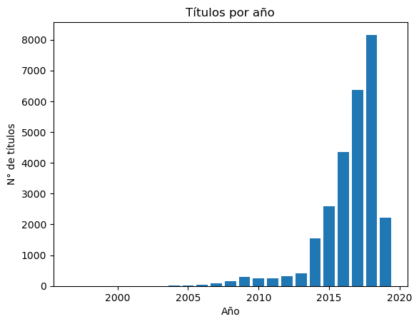

```python
import matplotlib.pyplot as plt

steam['release_date'] = pd.to_datetime(steam['release_date'])
steam['year'] = steam['release_date'].dt.year.astype(int)

# Calcular el recuento de títulos por año
title_counts = steam['year'].value_counts().sort_index()

# Crear el gráfico de barras
plt.bar(title_counts.index, title_counts.values)

# Establecer títulos y etiquetas de los ejes
plt.title("Títulos por año")
plt.xlabel("Año")
plt.ylabel("N° de títulos")



# Mostrar el gráfico
plt.show()
```

Juegos que tienen uno o mas géneros en específico

```python
steam2 = steam[steam['genres'].str.contains('Action')]
steam3 = steam[steam['genres'].str.contains('Strategy') & steam['genres'].str.contains('RPG')]
steam2.head()
steam3.head()
```

|  | appid | name | release_date | english | developer | publisher | platforms | required_age | categories | genres | steamspy_tags | achievements | positive_ratings | negative_ratings | average_playtime | median_playtime | owners | price | year |
| --- | --- | --- | --- | --- | --- | --- | --- | --- | --- | --- | --- | --- | --- | --- | --- | --- | --- | --- | --- |
| 86 | 3170 | King's Bounty: Armored Princess | 2009-11-19 | 1 | Katauri Interactive | 1C Entertainment | windows;mac | 0 | Single-player;Steam Cloud | RPG;Strategy | RPG;Turn-Based Strategy;Strategy | 0 | 482 | 53 | 1422 | 1429 | 200000-500000 | 7.99 | 2009 |
| 215 | 8500 | EVE Online | 2010-12-15 | 1 | CCP | CCP | windows;mac | 0 | Multi-player;Online Multi-Player;MMO;Co-op;Onl... | Action;Free to Play;Massively Multiplayer;RPG;... | Space;Massively Multiplayer;Sci-fi | 0 | 8317 | 2832 | 5123 | 230 | 1000000-2000000 | 0.00 | 2010 |
| 220 | 8880 | Freedom Force | 2009-05-29 | 1 | Irrational Games | 2K | windows | 0 | Single-player;Multi-player | RPG;Strategy | RPG;Strategy;Superhero | 0 | 197 | 150 | 16 | 16 | 200000-500000 | 2.99 | 2009 |
| 221 | 8890 | Freedom Force vs. the Third Reich | 2009-05-29 | 1 | Irrational Games | 2K | windows | 0 | Single-player;Multi-player | RPG;Strategy | RPG;Strategy;Superhero | 0 | 121 | 28 | 23 | 23 | 200000-500000 | 2.99 | 2009 |
| 264 | 10270 | Disciples III: Reincarnation | 2014-02-14 | 1 | Akella | Kalypso Media Digital | windows | 0 | Single-player;Multi-player | RPG;Strategy | RPG;Turn-Based Strategy;Strategy | 0 | 618 | 252 | 889 | 889 | 50000-100000 | 9.99 | 2014 |

Juegos que poseen algún género en especíifics

```python
steam4 = steam[steam['genres'].str.contains('Strategy|Action')]
steam4.head()
```

|  | appid | name | release_date | english | developer | publisher | platforms | required_age | categories | genres | steamspy_tags | achievements | positive_ratings | negative_ratings | average_playtime | median_playtime | owners | price | year |
| --- | --- | --- | --- | --- | --- | --- | --- | --- | --- | --- | --- | --- | --- | --- | --- | --- | --- | --- | --- |
| 0 | 10 | Counter-Strike | 2000-11-01 | 1 | Valve | Valve | windows;mac;linux | 0 | Multi-player;Online Multi-Player;Local Multi-P... | Action | Action;FPS;Multiplayer | 0 | 124534 | 3339 | 17612 | 317 | 10000000-20000000 | 7.19 | 2000 |
| 1 | 20 | Team Fortress Classic | 1999-04-01 | 1 | Valve | Valve | windows;mac;linux | 0 | Multi-player;Online Multi-Player;Local Multi-P... | Action | Action;FPS;Multiplayer | 0 | 3318 | 633 | 277 | 62 | 5000000-10000000 | 3.99 | 1999 |
| 2 | 30 | Day of Defeat | 2003-05-01 | 1 | Valve | Valve | windows;mac;linux | 0 | Multi-player;Valve Anti-Cheat enabled | Action | FPS;World War II;Multiplayer | 0 | 3416 | 398 | 187 | 34 | 5000000-10000000 | 3.99 | 2003 |
| 3 | 40 | Deathmatch Classic | 2001-06-01 | 1 | Valve | Valve | windows;mac;linux | 0 | Multi-player;Online Multi-Player;Local Multi-P... | Action | Action;FPS;Multiplayer | 0 | 1273 | 267 | 258 | 184 | 5000000-10000000 | 3.99 | 2001 |
| 4 | 50 | Half-Life: Opposing Force | 1999-11-01 | 1 | Gearbox Software | Valve | windows;mac;linux | 0 | Single-player;Multi-player;Valve Anti-Cheat en... | Action | FPS;Action;Sci-fi | 0 | 5250 | 288 | 624 | 415 | 5000000-10000000 | 3.99 | 1999 |

Juegos que no poseen alguno o mas géneros en específico

```python
steam5 = steam[~steam['genres'].str.contains('Action')]
steam6 = steam[~steam['genres'].str.contains('Strategy|Action')]
steam5.head()
steam6.head()
```

|  | appid | name | release_date | english | developer | publisher | platforms | required_age | categories | genres | steamspy_tags | achievements | positive_ratings | negative_ratings | average_playtime | median_playtime | owners | price | year |
| --- | --- | --- | --- | --- | --- | --- | --- | --- | --- | --- | --- | --- | --- | --- | --- | --- | --- | --- | --- |
| 26 | 1002 | Rag Doll Kung Fu | 2005-10-12 | 1 | Mark Healey | Mark Healey | windows | 0 | Single-player;Multi-player | Indie | Indie;Fighting;Multiplayer | 0 | 40 | 17 | 0 | 0 | 20000-50000 | 5.99 | 2005 |
| 33 | 1530 | Multiwinia | 2008-09-19 | 1 | Introversion Software | Introversion Software | windows;mac | 0 | Single-player;Multi-player;Steam Achievements | Indie | Indie;RTS;Strategy | 12 | 368 | 75 | 121 | 224 | 500000-1000000 | 7.19 | 2008 |
| 40 | 1700 | Arx Fatalis | 2007-04-03 | 1 | Arkane Studios | Arkane Studios | windows | 0 | Single-player | RPG | RPG;First-Person;Classic | 0 | 671 | 106 | 11 | 21 | 100000-200000 | 2.99 | 2007 |
| 41 | 1840 | Source Filmmaker | 2012-07-10 | 1 | Valve | Valve | windows | 0 | Steam Workshop | Animation & Modeling;Video Production | Animation & Modeling;Video Production;Free to ... | 0 | 15083 | 1111 | 239 | 77 | 1000000-2000000 | 0.00 | 2012 |
| 43 | 1930 | Two Worlds Epic Edition | 2009-04-30 | 1 | Reality Pump Studios | Topware Interactive | windows;mac;linux | 0 | Single-player;Multi-player;Online Multi-Player... | RPG | RPG;Open World;Fantasy | 0 | 2656 | 1055 | 484 | 422 | 1000000-2000000 | 6.99 | 2009 |

Gráfico de top 10 juegos por cantidad de votos positivos

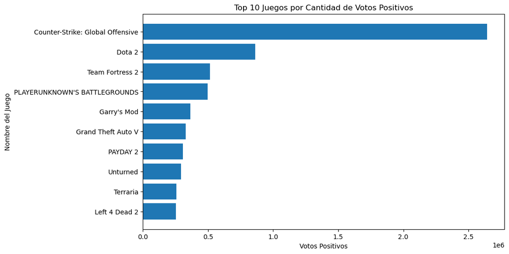

```python
import matplotlib.pyplot as plt

# Ordenamos el DataFrame por la columna 'positive_ratings' en orden descendente
df_sorted = steam.sort_values('positive_ratings', ascending=False)

# Seleccionamos las primeras 10 filas
top_10_games = df_sorted.head(10)

# Creamos el gráfico
plt.figure(figsize=(10, 6))
plt.barh(top_10_games['name'], top_10_games['positive_ratings'])
plt.title('Top 10 Juegos por Cantidad de Votos Positivos')
plt.xlabel('Votos Positivos')
plt.ylabel('Nombre del Juego')

# Invertimos el eje y para que el juego con más votos aparezca en la parte superior
plt.gca().invert_yaxis()

plt.show()
```

Cantidad de juegos por género

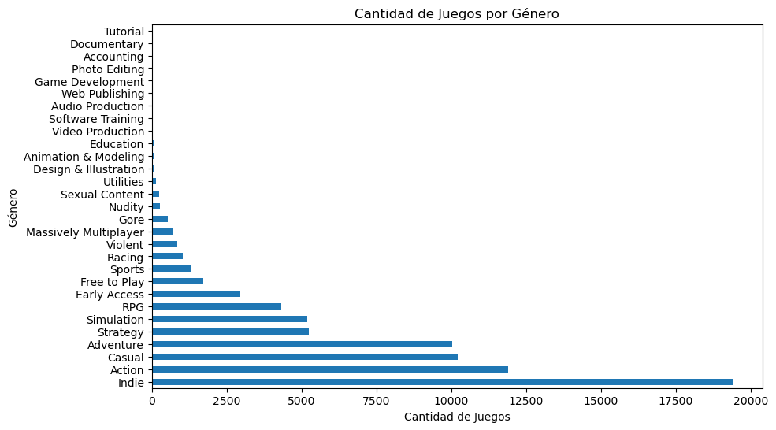

```python
import matplotlib.pyplot as plt

# Contamos la cantidad de juegos por género
genre_counts = steam['genres'].str.split(';').explode().value_counts()

# Creamos el gráfico
plt.figure(figsize=(10, 6))
genre_counts.plot(kind='barh')
plt.title('Cantidad de Juegos por Género')
plt.ylabel('Género')
plt.xlabel('Cantidad de Juegos')


plt.show()
```

Para transformar las columnas de strings en columnas binarias realizamos lo siguiente:

```python
import pandas as pd

# Dividimos las categorías y los géneros, y los apilamos para hacer un conteo cruzado
categories = steam['categories'].str.split(';', expand=True).stack().reset_index(level=1, drop=True).to_frame('categories')
genres = steam['genres'].str.split(';', expand=True).stack().reset_index(level=1, drop=True).to_frame('genres')
steamspy_tags = steam['steamspy_tags'].str.split(';', expand=True).stack().reset_index(level=1, drop=True).to_frame('steamspy_tags')
platforms = steam['platforms'].str.split(';', expand=True).stack().reset_index(level=1, drop=True).to_frame('platforms')

# Hacemos un conteo cruzado para obtener las columnas binarias
categories_binary = pd.get_dummies(categories, columns=['categories'], prefix='', prefix_sep='').groupby(level=0).sum()
genres_binary = pd.get_dummies(genres, columns=['genres'], prefix='', prefix_sep='').groupby(level=0).sum()
steamspy_tags = pd.get_dummies(steamspy_tags, columns=['steamspy_tags'], prefix='', prefix_sep='').groupby(level=0).sum()
platforms_binary = pd.get_dummies(platforms, columns=['platforms'], prefix='', prefix_sep='').groupby(level=0).sum()


# Unimos el dataframe original con las nuevas columnas de categorías y géneros
steam = pd.concat([steam, categories_binary, genres_binary, steamspy_tags], axis=1)

steam = steam.drop(columns=['categories', 'genres', 'steamspy_tags', 'platforms'])
```

### Experimento 1

Se detalla el código utilizado para el experimento preliminar que intenta contestar la pregunta 1 estipulada para este hito.

Tabla con las columnas numéricas relevantes.

```python
# Seleccionar las características numéricas
features = ['appid' , 'english' , 'required_age' , 'achievements' ,
            'positive_ratings' , 'negative_ratings' , 'average_playtime' ,
            'median_playtime' , 'price' , 'Captions available' ,
            'Co-op' , 'Commentary available' , 'Cross-Platform Multiplayer' ,
            'Full controller support' , 'In-App Purchases' ,
            'Includes Source SDK' , 'Includes level editor' , 'Local Co-op' ,
            'Local Multi-Player' , 'MMO' , 'Mods' , 'Mods (require HL2)' ,
            'Multi-player' , 'Online Co-op' , 'Online Multi-Player' ,
            'Partial Controller Support' , 'Shared/Split Screen' ,
            'Single-player' , 'Stats' , 'Steam Achievements' , 'Steam Cloud' ,
            'Steam Leaderboards' , 'Steam Trading Cards' ,
            'Steam Turn Notifications' , 'Steam Workshop' ,
            'SteamVR Collectibles' , 'VR Support' , 'Valve Anti-Cheat enabled' ,
            'Accounting' , 'Action' , 'Adventure' , 'Animation & Modeling' ,
            'Audio Production' , 'Casual' , 'Design & Illustration' ,
            'Documentary' , 'Early Access' , 'Education' , 'Free to Play' ,
            'Game Development' , 'Gore' , 'Indie' , 'Massively Multiplayer' ,
            'Nudity' , 'Photo Editing' , 'RPG' , 'Racing' , 'Sexual Content' ,
            'Simulation' , 'Software Training' , 'Sports' , 'Strategy' ,
            'Tutorial' , 'Utilities' , 'Video Production' , 'Violent' ,
            'Web Publishing' , '1980s' , "1990's" , '2.5D' , '2D' , '2D Fighter' ,
            '360 Video' , '3D' , '3D Platformer' , '3D Vision' , '4 Player Local' ,
            '4X' , '6DOF' , 'Abstract' , 'Action' , 'Action RPG' , 'Action-Adventure' ,
            'Adventure' , 'Agriculture' , 'Aliens' , 'Alternate History' , 'America' ,
            'Animation & Modeling' , 'Anime' , 'Arcade' , 'Arena Shooter' , 'Assassin' ,
            'Atmospheric' , 'Audio Production' , 'BMX' , 'Base-Building' , 'Baseball' ,
            'Basketball' , 'Batman' , 'Battle Royale' , "Beat 'em up" , 'Beautiful' ,
            'Benchmark' , 'Bikes' , 'Blood' , 'Board Game' , 'Bowling' , 'Building' ,
            'Bullet Hell' , 'Bullet Time' , 'CRPG' , 'Capitalism' , 'Card Game' , 'Cartoon' ,
            'Cartoony' , 'Casual' , 'Cats' , 'Character Action Game' , 'Character Customization' ,
            'Chess' , 'Choices Matter' , 'Choose Your Own Adventure' , 'Cinematic' ,
            'City Builder' , 'Class-Based' , 'Classic' , 'Clicker' , 'Co-op' , 'Cold War',
            'Colorful' , 'Comedy' , 'Comic Book' , 'Competitive' , 'Controller' ,
            'Conversation' , 'Crafting' , 'Crime' , 'Cult Classic' , 'Cute' , 'Cyberpunk' ,
            'Cycling' , 'Dark' , 'Dark Fantasy' , 'Dark Humor' , 'Dating Sim' , 'Demons' ,
            'Design & Illustration' , 'Destruction' , 'Detective' , 'Difficult' , 'Dinosaurs' ,
            'Diplomacy' , 'Documentary' , 'Dog' , 'Dragons' , 'Drama' , 'Driving' , 'Dungeon Crawler' ,
            'Dungeons & Dragons' , 'Dystopian ' , 'Early Access' , 'Economy' , 'Education' , 'Epic' , 'Experimental' ,
            'Exploration' , 'FMV' , 'FPS' , 'Faith' , 'Family Friendly' , 'Fantasy' , 'Fast-Paced' , 'Female Protagonist' ,
            'Fighting' , 'First-Person' , 'Fishing' , 'Flight' , 'Football' , 'Free to Play' , 'Funny' , 'Futuristic' ,
            'Gambling' , 'Game Development' , 'GameMaker' , 'Games Workshop' , 'God Game' , 'Golf' , 'Gore' , 'Gothic' ,
            'Grand Strategy' , 'Great Soundtrack' , 'Grid-Based Movement' , 'Gun Customization' , 'Hack and Slash' ,
            'Hacking' , 'Hand-drawn' , 'Heist' , 'Hex Grid' , 'Hidden Object' , 'Historical' , 'Hockey' , 'Horror' ,
            'Horses' , 'Hunting' , 'Illuminati' , 'Indie' , 'Intentionally Awkward Controls' , 'Interactive Fiction' ,
            'Inventory Management' , 'Investigation' , 'Isometric' , 'JRPG' , 'Kickstarter' , 'LEGO' , 'Lara Croft' ,
            'Lemmings' , 'Level Editor' , 'Linear' , 'Local Co-Op' , 'Local Multiplayer' , 'Logic' , 'Loot' , 'Lovecraftian' ,
            'MMORPG' , 'MOBA' , 'Magic' , 'Management' , 'Mars' , 'Martial Arts' , 'Massively Multiplayer' , 'Masterpiece' ,
            'Match 3' , 'Mature' , 'Mechs' , 'Medieval' , 'Memes' , 'Metroidvania' , 'Military' , 'Mini Golf' , 'Minimalist' ,
            'Mining' , 'Mod' , 'Moddable' , 'Motocross' , 'Motorbike' , 'Mouse only' , 'Movie' , 'Multiplayer' , 'Multiple Endings' ,
            'Music' , 'Music-Based Procedural Generation' , 'Mystery' , 'Mystery Dungeon' , 'Mythology' , 'NSFW' , 'Narration' , 'Naval' ,
            'Ninja' , 'Noir' , 'Nonlinear' , 'Nudity' , 'Offroad' , 'Old School' , 'On-Rails Shooter' , 'Online Co-Op' , 'Open World' ,
            'Otome' , 'Parkour' , 'Parody ' , 'Party-Based RPG' , 'Perma Death' , 'Philisophical' , 'Photo Editing' , 'Physics' ,
            'Pinball' , 'Pirates' , 'Pixel Graphics' , 'Platformer' , 'Point & Click' , 'Political' , 'Politics' , 'Pool' ,
            'Post-apocalyptic' , 'Procedural Generation' , 'Programming' , 'Psychedelic' , 'Psychological' , 'Psychological Horror' ,
            'Puzzle' , 'Puzzle-Platformer' , 'PvP' , 'Quick-Time Events' , 'RPG' , 'RPGMaker' , 'RTS' , 'Racing' , 'Real Time Tactics' ,
            'Real-Time' , 'Real-Time with Pause' , 'Realistic' , 'Relaxing' , 'Remake' , 'Replay Value' , 'Resource Management' , 'Retro' ,
            'Rhythm' , 'Robots' , 'Rogue-like' , 'Rogue-lite' , 'Romance' , 'Rome' , 'Runner' , 'Sailing' , 'Sandbox' , 'Satire' ,
            'Sci-fi' , 'Science' , 'Score Attack' , 'Sexual Content' , "Shoot 'Em Up" , 'Shooter' , 'Short' , 'Side Scroller' ,
            'Simulation' , 'Singleplayer' , 'Skateboarding' , 'Skating' , 'Sniper' , 'Snow' , 'Snowboarding' , 'Soccer' , 'Software' ,
            'Software Training' , 'Sokoban' , 'Souls-like' , 'Space' , 'Space Sim' , 'Spectacle fighter' , 'Spelling' , 'Split Screen' ,
            'Sports' , 'Star Wars' , 'Stealth' , 'Steampunk' , 'Story Rich' , 'Strategy' , 'Strategy RPG' , 'Stylized' , 'Submarine' ,
            'Superhero' , 'Supernatural' , 'Surreal' , 'Survival' , 'Survival Horror' , 'Swordplay' , 'Tactical' , 'Tactical RPG' ,
            'Tanks' , 'Team-Based' , 'Tennis' , 'Text-Based' , 'Third Person' , 'Third-Person Shooter' , 'Thriller' , 'Time Attack' ,
            'Time Management' , 'Time Manipulation' , 'Time Travel' , 'Top-Down' , 'Top-Down Shooter' , 'Touch-Friendly' , 'Tower Defense' ,
            'Trading' , 'Trading Card Game' , 'Trains' , 'Turn-Based' , 'Turn-Based Combat' , 'Turn-Based Strategy' , 'Turn-Based Tactics' ,
            'Twin Stick Shooter' , 'Typing' , 'Underwater' , 'Utilities' , 'VR' , 'VR Only' , 'Vampire' , 'Video Production' ,
            'Villain Protagonist' , 'Violent' , 'Visual Novel' , 'Voice Control' , 'Voxel' , 'Walking Simulator' , 'War' , 'Wargame' ,
            'Warhammer 40K' , 'Web Publishing' , 'Werewolves' , 'Western' , 'Word Game' , 'World War I' , 'World War II' , 'Wrestling' ,
            'Zombies' , 'e-sports']

columnas_numericas = ("english", "required_age", "achievements", "positive_ratings", "negative_ratings", "average_playtime", "median_playtime", "price")
X = steam[list(columnas_numericas)]
X.head()
```

|  | english | required_age | achievements | positive_ratings | negative_ratings | average_playtime | median_playtime | price |
| --- | --- | --- | --- | --- | --- | --- | --- | --- |
| 0 | 1 | 0 | 0 | 124534 | 3339 | 17612 | 317 | 7.19 |
| 1 | 1 | 0 | 0 | 3318 | 633 | 277 | 62 | 3.99 |
| 2 | 1 | 0 | 0 | 3416 | 398 | 187 | 34 | 3.99 |
| 3 | 1 | 0 | 0 | 1273 | 267 | 258 | 184 | 3.99 |
| 4 | 1 | 0 | 0 | 5250 | 288 | 624 | 415 | 3.99 |

Árbol de regresión lineal con el 80% de los datos para entrenar y el 20% restante para testear.

```python
from sklearn.tree import DecisionTreeRegressor
from sklearn.model_selection import train_test_split
from sklearn.metrics import mean_squared_error
x1= steam[list(features)]
clf = DecisionTreeRegressor()
y = x1.price
Xwp = x1.copy()
Xwp = Xwp.drop("price", axis=1)
clf.fit(Xwp, y)
X_train, X_test, y_train, y_test = train_test_split(Xwp, y, test_size=0.2, random_state=42)

regressor = DecisionTreeRegressor()
regressor.fit(X_train, y_train)

y_pred = regressor.predict(X_test)
mse = mean_squared_error(y_test, y_pred)
print("Mean Squared Error (MSE):", mse)
```

```
Mean Squared Error (MSE): 101.04994424746076
```

Juego ficticio con valores ficticios.

```python
#%%
import warnings
import random
warnings.filterwarnings("ignore")
lista_numeros = [random.randint(0, 1) for _ in range(398)]
# Valores de ejemplo para los otros atributos
english = 1
required_age = 18
achievements = 50
positive_ratings = 1000
negative_ratings = 200
average_playtime = 120
median_playtime = 90

# Preparar los valores de los atributos para la predicción
input_data = [english, required_age, achievements, positive_ratings, negative_ratings, average_playtime, median_playtime]
input_data = [input_data + lista_numeros]
# Realizar la predicción
predicted_price = regressor.predict(input_data)

# Imprimir el valor predicho
print("Predicted Price:", predicted_price)
```

```
Predicted Price: [10.99]
```

Discretizaremos para pasar a clasificar.

```python
df=steam[list(features)].copy()
intervals = [-1,10,20,30,40,50,float('inf')]
labels = ['0-10', '10-20', '20-30', '30-40','40-50','>50']

df['intervaloprecio'] = pd.cut(df['price'], bins=intervals, labels=labels)
y=df.intervaloprecio
dfwp = df.copy()
dfwp = dfwp.drop("intervaloprecio", axis=1)
dfwp = dfwp.drop("price", axis=1)
```

Creamos el árbol de decisión y observamos métricas.

```python
from sklearn.tree import DecisionTreeClassifier
from sklearn.metrics import accuracy_score
from sklearn.metrics import classification_report


X_train, X_test, y_train, y_test = train_test_split(dfwp, y, test_size=.3, random_state=1,
                                                    stratify=y)
clf = DecisionTreeClassifier()
clf.fit(X_train, y_train)
y_pred = clf.predict(X_test)
print("Accuracy:", accuracy_score(y_test, y_pred))
print(classification_report(y_test, y_pred))
```

```
Accuracy: 0.769789486642866
              precision    recall  f1-score   support

        0-10       0.88      0.87      0.88      6646
       10-20       0.31      0.33      0.32      1200
       20-30       0.19      0.18      0.19       180
       30-40       0.22      0.19      0.21        63
       40-50       0.19      0.17      0.18        23
         >50       0.20      0.09      0.13        11

    accuracy                           0.77      8123
   macro avg       0.33      0.31      0.32      8123
weighted avg       0.77      0.77      0.77      8123
```

Generamos matriz de confusión asociada.

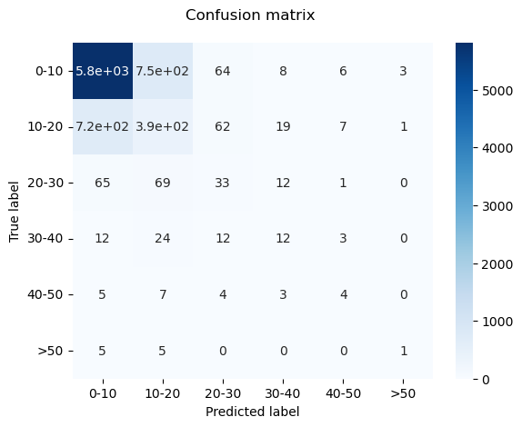

```python
import seaborn as sns
import matplotlib.pyplot as plt

from sklearn.metrics import confusion_matrix
from sklearn.utils.multiclass import unique_labels


cm = confusion_matrix(y_test, y_pred)

classes = unique_labels(y_test, y_pred)

df = pd.DataFrame(cm, index=classes, columns=classes)

g = sns.heatmap(df, annot=True, cmap="Blues")
g.set_yticklabels(g.get_yticklabels(), rotation=0)

plt.title('Confusion matrix \n')
plt.xlabel('Predicted label')
plt.ylabel('True label')

plt.autoscale()
```

Hacemos Cross validation.

```python
from sklearn.model_selection import cross_validate
import numpy as np

scoring = ['precision_macro', 'recall_macro', 'accuracy', 'f1_macro']
cv_results = cross_validate(
    clf, dfwp, y, cv=10, scoring=scoring, return_train_score=True)

print('Promedio Precision:', np.mean(cv_results['test_precision_macro']))
print('Promedio Recall:', np.mean(cv_results['test_recall_macro']))
print('Promedio F1-score:', np.mean(cv_results['test_f1_macro']))
print('Promedio Accucary:', np.mean(cv_results['test_accuracy']))

print('Promedio Precision k-fold:', cv_results['test_precision_macro'])
print('Promedio Recall k-fold:', cv_results['test_recall_macro'])
print('Promedio F1-score k-fold:', cv_results['test_f1_macro'])
print('Promedio Accucary k-fold:', cv_results['test_accuracy'])
```

```
Promedio Precision: 0.2174362697001333
Promedio Recall: 0.18531936820796766
Promedio F1-score: 0.1716672160551054
Promedio Accucary: 0.3848703836380215
Promedio Precision k-fold: [0.25489456 0.11991908 0.1742464  0.17913852 0.19774722 0.2299454
 0.25247114 0.18864081 0.21055261 0.36680697]
Promedio Recall k-fold: [0.22201715 0.06368682 0.1555231  0.16314554 0.1832391  0.25289978
 0.21687995 0.16391585 0.18933073 0.24255567]
Promedio F1-score k-fold: [0.0916554  0.07384752 0.15635944 0.15694819 0.18268305 0.22459096
 0.22380294 0.15380162 0.18313672 0.26984631]
Promedio Accucary k-fold: [0.07754801 0.21011817 0.40029542 0.42946824 0.44128508 0.41854451
 0.42076099 0.29737717 0.34983376 0.80347248]
```

Creamos las muestras con over y undersampling.

```python
from imblearn.over_sampling import SMOTE
from imblearn.under_sampling import TomekLinks
overdf = steam[list(columnas_numericas)].copy()
overdf['intervaloprecio'] = pd.cut(overdf['price'], bins=intervals, labels=labels)
overDfY = overdf['intervaloprecio']
overDfX = overdf[list(columnas_numericas)]
overDfX = overDfX.drop("price", axis=1)
smote = SMOTE()
X_smote, Y_smote = smote.fit_resample(overDfX, overDfY)

tomek = TomekLinks()
X_tomek, y_tomek = tomek.fit_resample(overDfX, overDfY)
print("Tamaño del conjunto de datos original:")
print(overDfY.value_counts())

print("\nTamaño del conjunto de datos después del sobremuestreo (SMOTE):")
print(Y_smote.value_counts())
print("\nTamaño del conjunto de datos después del submuestreo (Tomek Links):")
print(y_tomek.value_counts())
```

```
Tamaño del conjunto de datos original:
0-10     22153
10-20     3999
20-30      600
30-40      208
40-50       77
>50         38
Name: intervaloprecio, dtype: int64

Tamaño del conjunto de datos después del sobremuestreo (SMOTE):
0-10     22153
10-20    22153
20-30    22153
30-40    22153
40-50    22153
>50      22153
Name: intervaloprecio, dtype: int64

Tamaño del conjunto de datos después del submuestreo (Tomek Links):
0-10     20905
10-20     2808
20-30      346
30-40      127
40-50       38
>50         38
Name: intervaloprecio, dtype: int64
```

Repetimos lo mismo que en la muestra normal con oversampling.

```python
X_sobretrain, X_sobretest, y_sobretrain, y_sobretest = train_test_split(X_smote, Y_smote, test_size=.3, random_state=1,
                                                    stratify=Y_smote)
clfO = DecisionTreeClassifier()
clfO.fit(X_sobretrain, y_sobretrain)
y_sobrepred = clfO.predict(X_sobretest)
print("Accuracy:", accuracy_score(y_sobretest, y_sobrepred))
print(classification_report(y_sobretest, y_sobrepred))
```

```
Accuracy: 0.8075784933293209
              precision    recall  f1-score   support

        0-10       0.61      0.60      0.60      6646
       10-20       0.69      0.64      0.66      6646
       20-30       0.84      0.82      0.83      6646
       30-40       0.90      0.91      0.91      6646
       40-50       0.94      0.95      0.95      6646
         >50       0.85      0.93      0.89      6646

    accuracy                           0.81     39876
   macro avg       0.80      0.81      0.81     39876
weighted avg       0.80      0.81      0.81     39876
```

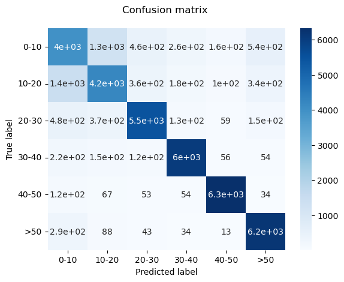

```python
cmO = confusion_matrix(y_sobretest, y_sobrepred)

classes = unique_labels(y_sobretest, y_sobrepred)

dfO = pd.DataFrame(cmO, index=classes, columns=classes)

g = sns.heatmap(dfO, annot=True, cmap="Blues")
g.set_yticklabels(g.get_yticklabels(), rotation=0)

plt.title('Confusion matrix \n')
plt.xlabel('Predicted label')
plt.ylabel('True label')

plt.autoscale()
```

```python
cv_results = cross_validate(
    clfO, X_smote, Y_smote, cv=10, scoring=scoring, return_train_score=True)

print('Promedio Precision:', np.mean(cv_results['test_precision_macro']))
print('Promedio Recall:', np.mean(cv_results['test_recall_macro']))
print('Promedio F1-score:', np.mean(cv_results['test_f1_macro']))
print('Promedio Accucary:', np.mean(cv_results['test_accuracy']))

print('Promedio Precision k-fold:', cv_results['test_precision_macro'])
print('Promedio Recall k-fold:', cv_results['test_recall_macro'])
print('Promedio F1-score k-fold:', cv_results['test_f1_macro'])
print('Promedio Accucary k-fold:', cv_results['test_accuracy'])
```

```
Promedio Precision: 0.8141252669606805
Promedio Recall: 0.8172198193316003
Promedio F1-score: 0.8148487257291572
Promedio Accucary: 0.8172182407401097
Promedio Precision k-fold: [0.79342942 0.7853887  0.80768212 0.81932063 0.82072641 0.82562185
 0.82262987 0.82229227 0.8209197  0.82324168]
Promedio Recall k-fold: [0.8008753  0.79093704 0.81177601 0.82222753 0.82350676 0.8270407
 0.82424365 0.82304106 0.82348777 0.82506238]
Promedio F1-score k-fold: [0.79548643 0.78780275 0.80941767 0.82040868 0.82181326 0.82589157
 0.82286499 0.82176486 0.82077198 0.82226507]
Promedio Accucary k-fold: [0.80085766 0.79092687 0.81176648 0.82222389 0.82350286 0.82703882
 0.82425519 0.82305146 0.82348958 0.8250696 ]
```

Repetimos para undersampling

```python
X_undertrain, X_undertest, y_undertrain, y_undertest = train_test_split(X_tomek, y_tomek, test_size=.3, random_state=1,stratify=y_tomek)
clfU = DecisionTreeClassifier()
clfU.fit(X_undertrain, y_undertrain)
y_underpred = clfU.predict(X_undertest)
print("Accuracy:", accuracy_score(y_undertest, y_underpred))
print(classification_report(y_undertest, y_underpred))
```

```
Accuracy: 0.8058799285616156
              precision    recall  f1-score   support

        0-10       0.89      0.91      0.90      6272
       10-20       0.23      0.19      0.21       843
       20-30       0.07      0.06      0.06       104
       30-40       0.07      0.08      0.07        38
       40-50       0.00      0.00      0.00        11
         >50       0.00      0.00      0.00        11

    accuracy                           0.81      7279
   macro avg       0.21      0.21      0.21      7279
weighted avg       0.79      0.81      0.80      7279
```

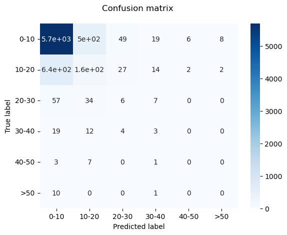

```python
cmU = confusion_matrix(y_undertest, y_underpred)

classes = unique_labels(y_undertest, y_underpred)

dfU = pd.DataFrame(cmU, index=classes, columns=classes)

g = sns.heatmap(dfU, annot=True, cmap="Blues")
g.set_yticklabels(g.get_yticklabels(), rotation=0)

plt.title('Confusion matrix \n')
plt.xlabel('Predicted label')
plt.ylabel('True label')

plt.autoscale()
```

```python
cv_results = cross_validate(
    clfU, X_tomek, y_tomek, cv=10, scoring=scoring, return_train_score=True)

print('Promedio Precision:', np.mean(cv_results['test_precision_macro']))
print('Promedio Recall:', np.mean(cv_results['test_recall_macro']))
print('Promedio F1-score:', np.mean(cv_results['test_f1_macro']))
print('Promedio Accucary:', np.mean(cv_results['test_accuracy']))

print('Promedio Precision k-fold:', cv_results['test_precision_macro'])
print('Promedio Recall k-fold:', cv_results['test_recall_macro'])
print('Promedio F1-score k-fold:', cv_results['test_f1_macro'])
print('Promedio Accucary k-fold:', cv_results['test_accuracy'])
```

```
Promedio Precision: 0.21441246665094388
Promedio Recall: 0.21115386590270488
Promedio F1-score: 0.2086430824574636
Promedio Accucary: 0.8095832607268261
Promedio Precision k-fold: [0.20638306 0.21213479 0.19623018 0.22812619 0.21472962 0.23957104
 0.26608548 0.18236423 0.20729451 0.19120556]
Promedio Recall k-fold: [0.24054513 0.2228325  0.19530306 0.21975272 0.21887763 0.22278026
 0.25333786 0.17797113 0.18424819 0.17589017]
Promedio F1-score k-fold: [0.2136548  0.21637102 0.19576369 0.22272599 0.21449275 0.22880763
 0.25223083 0.17802925 0.18806779 0.17628708]
Promedio Accucary k-fold: [0.72435105 0.78574372 0.79389942 0.82440231 0.81574608 0.82934872
 0.83676834 0.82440231 0.83264633 0.82852432]
```

### Experimento 2

Se detalla el código utilizado para el experimento que contesta la pregunta 2. Para esto se necesita usar clustering, y para ello se usa el método del codo para observar los clusters óptimos para trabajar.

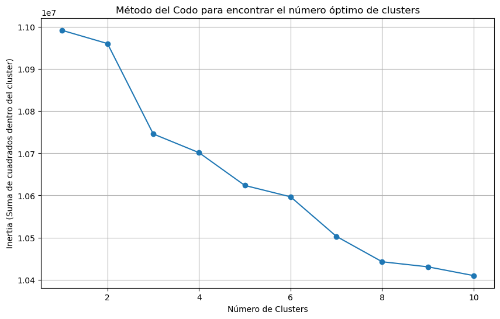

```python
#GRAFICO CODO/ SILUETA
import pandas as pd
import numpy as np
from sklearn.preprocessing import StandardScaler
from sklearn.cluster import KMeans
from sklearn.decomposition import PCA
from sklearn.metrics import silhouette_score
import matplotlib.pyplot as plt
# Cargar el DataFrame con los datos
wd = os.path.abspath(os.path.join(os.getcwd(), os.pardir, "db"))
os.chdir(wd)

steam = pd.read_csv("steam_transformado.csv")
data = steam

# Preprocesamiento: normalizar las características numéricas
scaler = StandardScaler()
data_scaled = scaler.fit_transform(data[features])

# Aplicar PCA para reducir la dimensionalidad de los datos
pca = PCA(n_components=2)
data_pca = pca.fit_transform(data_scaled)

# Evaluar el número óptimo de clusters utilizando el método del codo
inertia = []
silhouette_scores = []
max_clusters = 10

for num_clusters in range(1, max_clusters + 1):
    kmeans = KMeans(n_clusters=num_clusters, random_state=42)
    kmeans.fit(data_scaled)
    inertia.append(kmeans.inertia_)
    if num_clusters > 1:
        silhouette_scores.append(silhouette_score(data_scaled, kmeans.labels_))

# Visualizar la variabilidad explicada por cada número de clusters
plt.figure(figsize=(10, 6))
plt.plot(range(1, max_clusters + 1), inertia, marker='o')
plt.xlabel('Número de Clusters')
plt.ylabel('Inertia (Suma de cuadrados dentro del cluster)')
plt.title('Método del Codo para encontrar el número óptimo de clusters')
plt.grid(True)
plt.show()
```

Al no haber algo tan claro, se recurre al puntaje de silueta, que probablemente será mas util.

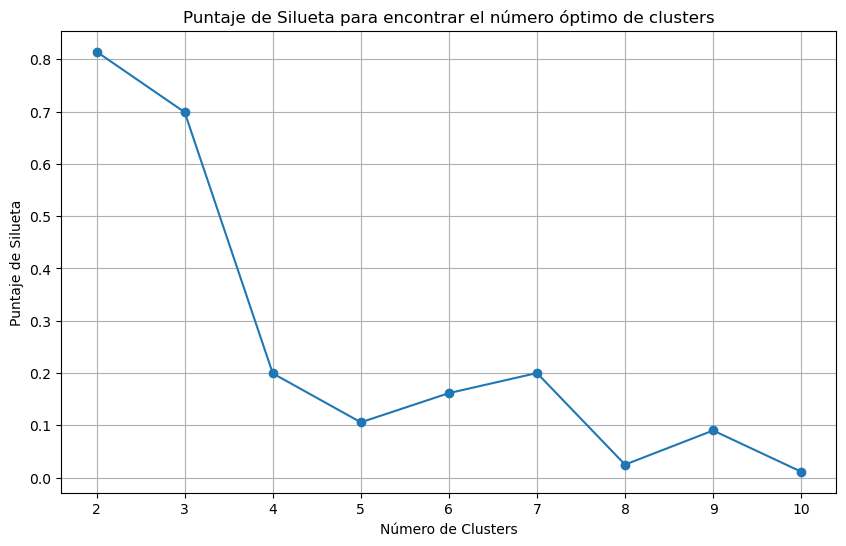

```python
# Visualizar el puntaje de silueta para cada número de clusters
plt.figure(figsize=(10, 6))
plt.plot(range(2, max_clusters + 1), silhouette_scores, marker='o')
plt.xlabel('Número de Clusters')
plt.ylabel('Puntaje de Silueta')
plt.title('Puntaje de Silueta para encontrar el número óptimo de clusters')
plt.grid(True)
plt.show()
```

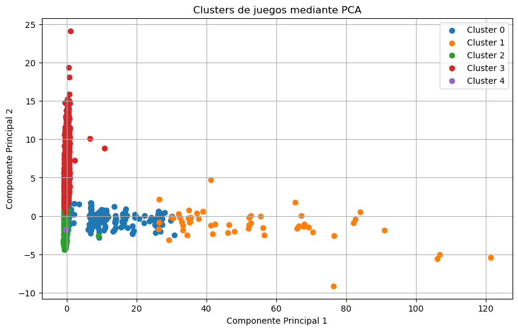

```python
num_clusters=5
kmeans = KMeans(n_clusters=num_clusters, random_state=42)
data['cluster'] = kmeans.fit_predict(data_scaled)

# Visualizar los clusters en un gráfico 2D con PCA
plt.figure(figsize=(10, 6))
for cluster_id in range(num_clusters):
    cluster_mask = data['cluster'] == cluster_id
    plt.scatter(data_pca[cluster_mask, 0], data_pca[cluster_mask, 1], label=f'Cluster {cluster_id}')

plt.xlabel('Componente Principal 1')
plt.ylabel('Componente Principal 2')
plt.title('Clusters de juegos mediante PCA')
plt.legend()
plt.grid(True)
plt.show()
```

Ahora se muestra un gráfico PCA con los clusters elegidos y asi observar las agrupaciones de juegos.

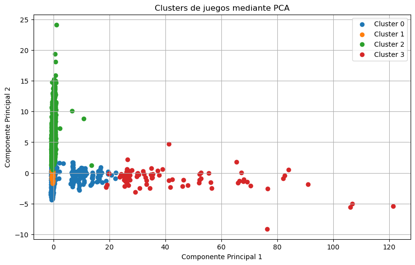

```python
num_clusters=4
kmeans = KMeans(n_clusters=num_clusters, random_state=42)
data['cluster'] = kmeans.fit_predict(data_scaled)

# Visualizar los clusters en un gráfico 2D con PCA
plt.figure(figsize=(10, 6))
for cluster_id in range(num_clusters):
    cluster_mask = data['cluster'] == cluster_id
    plt.scatter(data_pca[cluster_mask, 0], data_pca[cluster_mask, 1], label=f'Cluster {cluster_id}')

plt.xlabel('Componente Principal 1')
plt.ylabel('Componente Principal 2')
plt.title('Clusters de juegos mediante PCA')
plt.legend()
plt.grid(True)
plt.show()
```

Se desea realizar una revision por cantidad de si no ocurre lo mismo que con 5 clusters y se grafica.

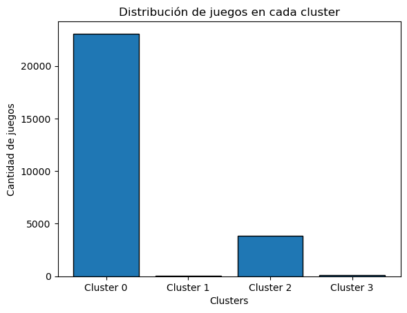

```python
# Preprocesamiento: normalizar las características numéricas
scaler = StandardScaler()
data_scaled = scaler.fit_transform(data[features])

# Definir el número de clusters que deseamos obtener
num_clusters = 4

# Aplicar K-Means para el clustering
kmeans = KMeans(n_clusters=num_clusters, random_state=42)
data['cluster'] = kmeans.fit_predict(data_scaled)

# Visualizar la distribución de los clusters
cluster_counts = data['cluster'].value_counts()
plt.bar(cluster_counts.index, cluster_counts.values, edgecolor='black')
plt.xlabel('Clusters')
plt.ylabel('Cantidad de juegos')
plt.title('Distribución de juegos en cada cluster')
plt.xticks(np.arange(num_clusters), labels=[f'Cluster {i}' for i in range(num_clusters)])
plt.show()
```

Ahora se necesita analizar las medias de cada clusters en cuando a ciertas columnas para responder si cada uno de estos clusters poseen alguna tendencia en cuanto al precio de los juegos.

```python
# Análisis de los clusters
cluster_stats = data.groupby('cluster')[features].mean()
print(cluster_stats)
```

```
                 appid   english  required_age  achievements  \
cluster
0        605534.053844  0.979597      0.329218     48.044661
1        492217.857143  1.000000      0.285714     28.767857
2        542452.335326  0.989862      0.518066     29.695347
3        564115.287356  0.988506      0.000000      1.758621

         positive_ratings  negative_ratings  average_playtime  \
cluster
0              472.021313         80.373576         93.598830
1             2185.946429        175.142857        192.535714
2             4157.747336        999.145048        487.255784
3              876.356322         53.068966        114.770115

         median_playtime      price  Captions available  ...  Warhammer 40K  \
cluster                                                  ...
0              93.338878   5.680880            0.027594  ...       0.000606
1             232.517857   9.619821            0.035714  ...       0.000000
2             462.093060   7.941066            0.020535  ...       0.003899
3             103.977011  26.850345            0.034483  ...       0.000000

         Web Publishing  Werewolves   Western  Word Game  World War I  \
cluster
0              0.000087    0.000087  0.000866    0.00039     0.000693
1              0.000000    0.000000  0.000000    0.00000     0.000000
2              0.000260    0.000260  0.000780    0.00026     0.001820
3              0.287356    0.000000  0.000000    0.00000     0.000000

         World War II  Wrestling   Zombies  e-sports
cluster
0            0.003812   0.000173  0.003899  0.000087
1            0.000000   0.000000  0.000000  0.000000
2            0.010918   0.001040  0.017676  0.000000
3            0.000000   0.000000  0.000000  0.000000

[4 rows x 406 columns]
```

Mostramos los primeros 5 juegos de cada cluster para comparar las etiquetas y características que poseen estos juegos y asi llegar a una relación entre estos para asi definir a cada uno.

```python
for cluster_id in range(num_clusters):
    print(f'\nCluster {cluster_id}')
    cluster_games = data[data['cluster'] == cluster_id]
    print(cluster_games[['name', 'developer', 'publisher']].head(5))
```

```
Cluster 0
                         name         developer publisher
4   Half-Life: Opposing Force  Gearbox Software     Valve
8       Half-Life: Blue Shift  Gearbox Software     Valve
9                 Half-Life 2             Valve     Valve
11          Half-Life: Source             Valve     Valve
14    Half-Life 2: Lost Coast             Valve     Valve

Cluster 1
                                name                   developer  \
506                          Aquaria               Bit Blot, LLC
1184                     Cave Story+  Nicalis, Inc.;Studio Pixel
1264  Insanely Twisted Shadow Planet   Shadow Planet Productions
1416        Guacamelee! Gold Edition            DrinkBox Studios
1636                       La-Mulana                      NIGORO

              publisher
506       Bit Blot, LLC
1184      Nicalis, Inc.
1264  Microsoft Studios
1416   DrinkBox Studios
1636        AGM PLAYISM

Cluster 2
                    name developer publisher
0         Counter-Strike     Valve     Valve
1  Team Fortress Classic     Valve     Valve
2          Day of Defeat     Valve     Valve
3     Deathmatch Classic     Valve     Valve
5               Ricochet     Valve     Valve

Cluster 3
                                                   name  \
1498                                   RPG Maker VX Ace
1697  Driver Fusion - The Best Driver & Device Solution
1904                               Clickteam Fusion 2.5
1988                              Leadwerks Game Engine
2041                      Axis Game Factory's AGFPRO v3

                  developer              publisher
1498               KADOKAWA                 Degica
1697                 Treexy                 Treexy
1904              Clickteam              Clickteam
1988     Leadwerks Software     Leadwerks Software
2041  Axis Game Factory LLC  Axis Game Factory LLC
```

### Experimento 3

A continuación, se muestra la matriz de correlación entre las características numéricas: "english", "required_age", "achievements", "positive_ratings", "negative_ratings", "average_playtime", "median_playtime" y "price".

```python
wd = os.path.abspath(os.path.join(os.getcwd(), os.pardir, "db"))
os.chdir(wd)

steam = pd.read_csv("steam.csv")
```

```python
columnas_numericas = ("english", "required_age", "achievements", "positive_ratings", "negative_ratings", "average_playtime", "median_playtime", "price")
X = steam[list(columnas_numericas)]
X.head()
```

|  | english | required_age | achievements | positive_ratings | negative_ratings | average_playtime | median_playtime | price |
| --- | --- | --- | --- | --- | --- | --- | --- | --- |
| 0 | 1 | 0 | 0 | 124534 | 3339 | 17612 | 317 | 7.19 |
| 1 | 1 | 0 | 0 | 3318 | 633 | 277 | 62 | 3.99 |
| 2 | 1 | 0 | 0 | 3416 | 398 | 187 | 34 | 3.99 |
| 3 | 1 | 0 | 0 | 1273 | 267 | 258 | 184 | 3.99 |
| 4 | 1 | 0 | 0 | 5250 | 288 | 624 | 415 | 3.99 |

```python
print("Correlación de Pearson de Positive ratings con respecto a las otras caracteristicas númericas")
correlation = X.corrwith(X['positive_ratings'], method='pearson')

print(correlation)
```

```
Correlación de Pearson de Positive ratings con respecto a las otras caracteristicas númericas
english             0.006001
required_age        0.060418
achievements        0.006058
positive_ratings    1.000000
negative_ratings    0.762804
average_playtime    0.157898
median_playtime     0.035776
price               0.036110
dtype: float64
```

```python
print("Correlación de Pearson de negative ratings con respecto a las otras caracteristicas númericas")

correlation = X.corrwith(X['negative_ratings'], method='pearson')

print(correlation)
```

```
Correlación de Pearson de negative ratings con respecto a las otras caracteristicas númericas
english             0.005705
required_age        0.057599
achievements        0.003578
positive_ratings    0.762804
negative_ratings    1.000000
average_playtime    0.161140
median_playtime     0.047887
price               0.051259
dtype: float64
```

Se puede observar como en ambas matrices la mayoría de características tienen valores cercanos al 0, como la característica "english" que posee un valor muy cercano a 0, lo que se puede interpretar como que da lo mismo si el juego esta en ingles o no.

```python
# Ahora, tambien vamos a hacer un analisis de regresión para ver como afecta de otra manera

from sklearn.linear_model import LinearRegression
from sklearn.model_selection import train_test_split

# Seleccionar las características (variables independientes)
features = X.drop('positive_ratings', axis=1)

# Seleccionar la variable objetivo
target = X['positive_ratings']

# Dividir el dataset en conjuntos de entrenamiento y prueba
X_train, X_test, y_train, y_test = train_test_split(features, target, test_size=0.2, random_state=42)

# Inicializar el modelo de regresión lineal
model = LinearRegression()

# Entrenar el modelo con los datos de entrenamiento
model.fit(X_train, y_train)

# Realizar predicciones en el conjunto de prueba
predictions = model.predict(X_test)

# Evaluar el rendimiento del modelo
score = model.score(X_test, y_test)

print("Coeficientes:", model.coef_)
print("Intercepto:", model.intercept_)
print("R^2:", score)
```

```
Coeficientes: [-1.02105053e+02 -1.05468495e+02  4.24157093e-02  5.62138139e+00
  1.04656379e+00 -6.92941327e-01 -5.24584650e+01]
Intercepto: 301.3417592616229
R^2: -8.398122088462364
```

```python
# Seleccionar las características (variables independientes)
features = X.drop('negative_ratings', axis=1)

# Seleccionar la variable objetivo
target = X['negative_ratings']

# Dividir el dataset en conjuntos de entrenamiento y prueba
X_train, X_test, y_train, y_test = train_test_split(features, target, test_size=0.2, random_state=42)

# Inicializar el modelo de regresión lineal
model = LinearRegression()

# Entrenar el modelo con los datos de entrenamiento
model.fit(X_train, y_train)

# Realizar predicciones en el conjunto de prueba
predictions = model.predict(X_test)

# Evaluar el rendimiento del modelo
score = model.score(X_test, y_test)

print("Coeficientes:", model.coef_)
print("Intercepto:", model.intercept_)
print("R^2:", score)
```

```
Coeficientes: [ 2.65227713e+01  2.71490556e+01 -1.23485999e-02  1.50247912e-01
  1.89109425e-01 -1.02302343e-01  9.99166072e+00]
Intercepto: -62.174830581406894
R^2: 0.2897987891716126
```

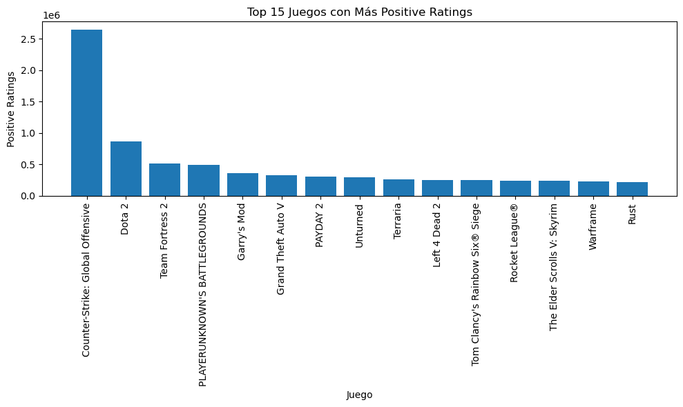

```python
sorted_steam = steam.sort_values('positive_ratings', ascending=False)

# Seleccionar los N juegos con más positive ratings
N = 15  # Número de juegos a mostrar
top_games = sorted_steam.head(N)

# Crear el gráfico de barras o gráfico de puntos
plt.figure(figsize=(10, 6))  # Tamaño del gráfico

# Opción 1: Gráfico de barras
plt.bar(top_games['name'], top_games['positive_ratings'])
plt.xlabel('Juego')
plt.ylabel('Positive Ratings')
plt.title(f'Top {N} Juegos con Más Positive Ratings')
plt.xticks(rotation=90)

plt.tight_layout()
plt.show()
```

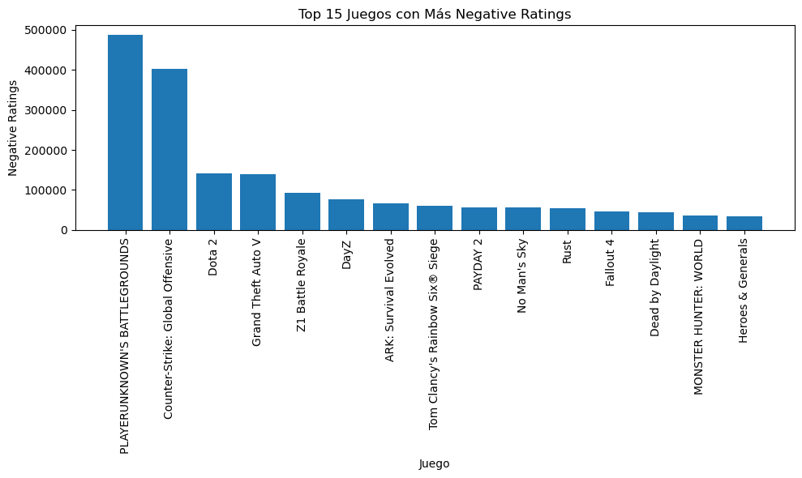

```python
sorted_steam = steam.sort_values('negative_ratings', ascending=False)

# Seleccionar los N juegos con más positive ratings
N = 15  # Número de juegos a mostrar
top_games = sorted_steam.head(N)

# Crear el gráfico de barras o gráfico de puntos
plt.figure(figsize=(10, 6))  # Tamaño del gráfico

# Opción 1: Gráfico de barras
plt.bar(top_games['name'], top_games['negative_ratings'])
plt.xlabel('Juego')
plt.ylabel('Negative Ratings')
plt.title(f'Top {N} Juegos con Más Negative Ratings')
plt.xticks(rotation=90)

plt.tight_layout()
plt.show()
```

### Experimento 4

Se detalla el código utilizado para el experimento que contesta la pregunta 4.

```python
#creamos una nueva columna con el porcentaje de criticas, la discretizamos y sacamos los valores NaN

steam['percentage_ratings'] = steam['positive_ratings'] * 100 / (steam['positive_ratings'] + steam['negative_ratings'])
steam['percentage_ratings'] = steam['percentage_ratings'].astype(int)
steam = steam.dropna(subset=['percentage_ratings'])
```

```python
# sacamos las columnas que no podemos evaluar o que son intrascendentes para un juego nuevo
steam1 = steam.drop(['percentage_ratings', 'appid', 'name', 'developer', 'publisher', 'positive_ratings', 'negative_ratings', 'release_date', 'owners', 'average_playtime', 'median_playtime'], axis = 1)
```

```python
#Arbol de decision clasificador

from sklearn.tree import DecisionTreeClassifier
from sklearn.model_selection import train_test_split, cross_val_score
from sklearn.metrics import accuracy_score

X = steam1
y = steam.percentage_ratings

X_train, X_test, y_train, y_test = train_test_split(X, y, test_size=0.33, random_state=23)
clf = DecisionTreeClassifier()
clf.fit(X_train, y_train)   ## Entrenar usando X (features), y (clase)

y_pred = clf.predict(X_test)   ## Predecimos con nuevos datos (los de test X_test)

print("Accuracy:", accuracy_score(y_test, y_pred))   ## Evaluamos la predicción comparando y_test con y_pred
```

```
Accuracy: 0.049244543928371576
```

```python
# Obtener la importancia de cada atributo en el árbol de decisión
importance = clf.feature_importances_

# Asociar los nombres de los atributos a su importancia
importants = dict(zip(X.columns, importance))

# Ordenar los atributos por su importancia de mayor a menor
importants = {k: v for k, v in sorted(importants.items(), key=lambda item: item[1], reverse=True)}

# Mostrar los atributos más importantes del árbol de decisión
print("Los 10 atributos más importantes del árbol de decisión:")
for i, (atributo, importancia) in enumerate(importants.items()):
    if i < 10:
        print(f"{atributo}: {importancia}")
```

```
Los 10 atributos más importantes del árbol de decisión:
price: 0.14450986391288334
achievements: 0.13083047509653273
Partial Controller Support: 0.030526192454789783
Adventure: 0.025920396885911853
Full controller support: 0.025369686336947004
Steam Cloud: 0.02181519183734653
Action: 0.021799999595276034
Adventure.1: 0.021293055089338594
Steam Leaderboards: 0.0211281037153438
Action.1: 0.020883604974990127
```

```python
# Modelo de Regresión Lineal

from sklearn.linear_model import LinearRegression
from sklearn.metrics import mean_squared_error, r2_score
import numpy as np

regresor_lineal = LinearRegression()
regresor_lineal.fit(X_train, y_train)

# Calcular el Mean Squared Error (MSE)
mse = mean_squared_error(y_test, y_pred)
print("Mean Squared Error (MSE):", mse)

# Calcular el R-squared (R2)
r2 = r2_score(y_test, y_pred)
print("R-squared (R2):", r2)

# Validación cruzada de Mean Squared Error (MSE)
cv_scores = cross_val_score(regresor_lineal, X, y, cv=5, scoring='neg_mean_squared_error')
mse_cv = -np.mean(cv_scores)
print("Cross-Validated Mean Squared Error (MSE):", mse_cv)

# Validación cruzada de R-squared (R2)
r2_cv_scores = cross_val_score(regresor_lineal, X, y, cv=5, scoring='r2')
r2_cv = np.mean(r2_cv_scores)
print("Cross-Validated R-squared (R2):", r2_cv)
```

```
Mean Squared Error (MSE): 972.2461108002238
R-squared (R2): -0.7571012747631645
Cross-Validated Mean Squared Error (MSE): 3.006141492278236e+18
Cross-Validated R-squared (R2): -8394726040158070.0
```

```python
# Modelo de regresión Random Forest

from sklearn.ensemble import RandomForestRegressor

regressor = RandomForestRegressor()
regressor.fit(X_train, y_train)

y_pred = regressor.predict(X_test)

# Calcular el Mean Squared Error (MSE)
mse = mean_squared_error(y_test, y_pred)
print("Mean Squared Error (MSE):", mse)

# Calcular el R-squared (R2)
r2 = r2_score(y_test, y_pred)
print("R-squared (R2):", r2)

# Validación cruzada de Mean Squared Error (MSE)
cv_scores = cross_val_score(regressor, X, y, cv=5, scoring='neg_mean_squared_error')
mse_cv = -np.mean(cv_scores)
print("Cross-Validated Mean Squared Error (MSE):", mse_cv)

# Validación cruzada de R-squared (R2)
r2_cv_scores = cross_val_score(regressor, X, y, cv=5, scoring='r2')
r2_cv = np.mean(r2_cv_scores)
print("Cross-Validated R-squared (R2):", r2_cv)
```

```
Mean Squared Error (MSE): 526.9416315646575
R-squared (R2): 0.04767959237607855
Cross-Validated Mean Squared Error (MSE): 541.5072130419201
Cross-Validated R-squared (R2): 0.007652157733811093
```